# Meta-analysis of Cohen’s d - From structuring the dataset to (not actually so) basic analyses

Author

Enrico Toffalini

## Dataset for a meta-analysis of a Cohen’s d / Standardized Mean Difference

Here is an example of a small dataset for meta-analyzing a Standardized Mean Difference (Cohen’s d). Data from 20 studies is reported. This may represent on the efficacy of a treatment (for simplicity here considering only the post-test scores) or on any other case involving comparing mean scores. “yearPub” and “weeks” might be moderators of interest.

```
 StudyID yearPub N_TG   M_TG SD_TG N_CG  M_CG SD_CG weeks
       1    2022   55  46.81  3.92   53 43.07  3.88    21
       2    2007   66  72.29  5.83   63 68.18  5.34    18
       3    2011  110  37.26  3.97  110 34.40  3.23    21
       4    2008  103  54.74  5.42  102 50.16  4.74    16
       5    2016  111 103.30  9.78  109 94.42  9.54    16
       6    2006   10  48.66  3.52    9 43.28  2.14    21
       7    2011   60  61.40  6.39   58 57.51  7.57     5
       8    2018  116  65.50  5.39  115 60.12  4.98    15
       9    2002   25  19.18  1.49   24 16.98  1.64    20
      10    2021   76  22.21  2.03   74 20.13  2.08    19
      11    2008   12  80.84 10.40   12 67.10  4.98    15
      12    2020   56  34.10  2.58   54 31.61  2.67    22
      13    2008  119  17.24  1.84  119 16.36  1.78    14
      14    2008   97  90.40  8.01   96 87.40  8.47    10
      15    2011   26  77.10  8.51   25 73.20  7.12     6
      16    2021   18  49.22  4.02   16 46.56  3.61     7
      17    2021   43  51.98  3.83   41 49.54  4.39    11
      18    2009   93  56.55  4.14   92 52.80  4.09    15
      19    2019  106  90.11  6.22  104 82.74  6.89    18
      20    2023  100  98.13  8.84   99 92.98  6.73    13
```

#### 1. Compute the effect sizes

Typically, adequate estimates of Standardized Mean Differences are not already reported in the articles, so you have to compute them yourself. Luckily, they can be computed from descriptive statistics that are generally reported (N, M, SD).

Since it is very clear that different studies used completely different instruments (note the variability across descriptive statistics), effect size **must** be standardized. Also, since some studies present very small samples, Hedges’ correction of Cohen’s d (Hedges’ g is preferred). Luckily, the “`measure="SMD"`” argument in the “`escalc`” function of the “`metafor`” package already applies Hedges’ correction for small samples.

```
 StudyID yearPub N_TG   M_TG SD_TG N_CG  M_CG SD_CG weeks     yi     vi
       1    2022   55  46.81  3.92   53 43.07  3.88    21 0.9521 0.0412
       2    2007   66  72.29  5.83   63 68.18  5.34    18 0.7301 0.0331
       3    2011  110  37.26  3.97  110 34.40  3.23    21 0.7876 0.0196
       4    2008  103  54.74  5.42  102 50.16  4.74    16 0.8959 0.0215
       5    2016  111 103.30  9.78  109 94.42  9.54    16 0.9159 0.0201
       6    2006   10  48.66  3.52    9 43.28  2.14    21 1.7406 0.2908
       7    2011   60  61.40  6.39   58 57.51  7.57     5 0.5525 0.0352
       8    2018  116  65.50  5.39  115 60.12  4.98    15 1.0332 0.0196
       9    2002   25  19.18  1.49   24 16.98  1.64    20 1.3830 0.1012
      10    2021   76  22.21  2.03   74 20.13  2.08    19 1.0071 0.0301
      11    2008   12  80.84 10.40   12 67.10  4.98    15 1.6269 0.2218
      12    2020   56  34.10  2.58   54 31.61  2.67    22 0.9421 0.0404
      13    2008  119  17.24  1.84  119 16.36  1.78    14 0.4846 0.0173
      14    2008   97  90.40  8.01   96 87.40  8.47    10 0.3626 0.0211
      15    2011   26  77.10  8.51   25 73.20  7.12     6 0.4885 0.0808
      16    2021   18  49.22  4.02   16 46.56  3.61     7 0.6775 0.1248
      17    2021   43  51.98  3.83   41 49.54  4.39    11 0.5878 0.0497
      18    2009   93  56.55  4.14   92 52.80  4.09    15 0.9075 0.0238
      19    2019  106  90.11  6.22  104 82.74  6.89    18 1.1194 0.0220
      20    2023  100  98.13  8.84   99 92.98  6.73    13 0.6526 0.0212
```

#### 2. Intercept-only model

Traditionally, a first good step is to test the “intercept-only model”. This computes nothing but a meta-analytic “weighted average”, plus the estimated heterogeneity (unless you set “`method="EE"`” for a fixed-effects [Equal-Effects] model, which is generally suboptimal).

Just doing this is very simple:

```r
fit0 = rma(yi, vi, data=df)

summary(fit0)
```

```
Random-Effects Model (k = 20; tau^2 estimator: REML)

  logLik  deviance       AIC       BIC      AICc
 -3.9216    7.8432   11.8432   13.7321   12.5932

tau^2 (estimated amount of total heterogeneity): 0.0326 (SE = 0.0215)
tau (square root of estimated tau^2 value):      0.1806
I^2 (total heterogeneity / total variability):   50.57%
H^2 (total variability / sampling variability):  2.02

Test for Heterogeneity:
Q(df = 19) = 40.9222, p-val = 0.0025

Model Results:

estimate      se     zval    pval   ci.lb   ci.ub
  0.8202  0.0593  13.8238  <.0001  0.7039  0.9365  ***

---
Signif. codes:  0 '***' 0.001 '**' 0.01 '*' 0.05 '.' 0.1 ' ' 1
```

Any comment about…

… the overall mean effect?

… the heterogeneity?

Lastly, let’s have a look at the forest plot:

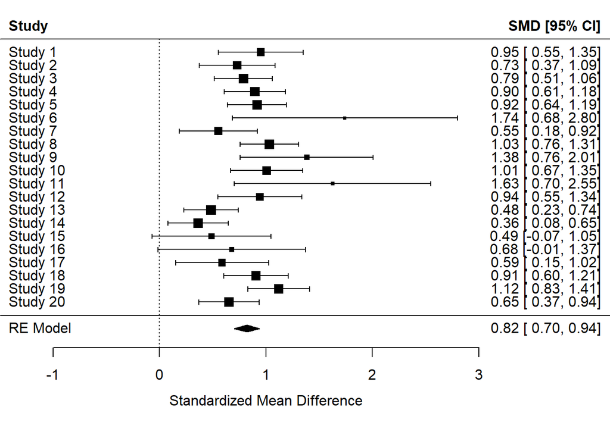

```r
par(mar=c(5,0,0,0))

forest(fit0, header=T)
```

#### 3. Testing moderator(s)

Would you proceed to test moderators in this case? why?

Now let’s fit a few alternative models with “moderators”. Practically, moderators are just linear predictors of the effect size. They are often called “moderators” instead of just “predictors” because the dependent variable is an effect size instead of a score (e.g., if you “predict” a SMD you are practically saying that this predictor “moderates” the effect of Group -> Score).

These may be some alternative models including moderators:

```r
fit1 = rma(yi, vi, mods=~weeks+yearPub, data=df)
fit2 = rma(yi, vi, mods=~yearPub, data=df)
fit3 = rma(yi, vi, mods=~weeks, data=df)
```

First, let’s see whether adding both moderators “in block” improves the model (compared to the original intercept-only model). We need to set “`refit=TRUE`” because only models fitted with Maximum Likelihood can be directly compared, while models fitted with Restricted Maximum Likelihood (which is the default) cannot be directly compared.

```r
anova(fit0, fit1, refit=T)
```

```
        df     AIC     BIC    AICc  logLik     LRT   pval      QE  tau^2
Full     4  4.0258  8.0087  6.6925  1.9871                23.8131 0.0051
Reduced  2 10.9975 12.9890 11.7034 -3.4988 10.9717 0.0041 40.9222 0.0290
             R^2
Full
Reduced 82.2986%
```

“`Full`” model means the one with **more** parameters (i.e., the one including the predictors/moderators). “`Reduced`” model measn the one with **less** parameters (i.e., the one including no predictors/moderators, or fewer of them).

After having established that entering moderators contributes to meaningfully explain heterogeneity (*BTW, how much?*), we can see whether each of them is “significant” when taken alone. So, we separately remove them from the “full” model. IMPORTANT: this procedure is just one among many possible alternatives! You may proceed to test moderators in the exact same way as you would proceed when testing predictors in any linear regression models!

```r
anova(fit1, fit2, refit=T)
```

```
        df     AIC     BIC    AICc  logLik     LRT   pval      QE  tau^2
Full     4  4.0258  8.0087  6.6925  1.9871                23.8131 0.0051
Reduced  3 12.5945 15.5817 14.0945 -3.2973 10.5687 0.0012 38.1367 0.0242
             R^2
Full
Reduced 78.7269%
```

In the above comparison, we tested “`fit2`” (without “`weeks`”) against “`fit1`” (with both “`weeks`” and “`yearPub`”). Any comment?

```r
anova(fit1, fit3, refit=T)
```

```
        df    AIC    BIC   AICc logLik    LRT   pval      QE  tau^2      R^2
Full     4 4.0258 8.0087 6.6925 1.9871               23.8131 0.0051
Reduced  3 2.5743 5.5615 4.0743 1.7129 0.5484 0.4590 24.9657 0.0084 38.7137%
```

In the above comparison, we tested “`fit3`” (without “`pubYear`”) against “`fit1`” (with both “`weeks`” and “`yearPub`”). Any comment?

Now, let’s see the summary of the final “best-fitting” model:

```r
summary(fit3)
```

```
Mixed-Effects Model (k = 20; tau^2 estimator: REML)

  logLik  deviance       AIC       BIC      AICc
  0.5546   -1.1092    4.8908    7.5619    6.6051

tau^2 (estimated amount of residual heterogeneity):     0.0119 (SE = 0.0142)
tau (square root of estimated tau^2 value):             0.1091
I^2 (residual heterogeneity / unaccounted variability): 27.19%
H^2 (unaccounted variability / sampling variability):   1.37
R^2 (amount of heterogeneity accounted for):            63.50%

Test for Residual Heterogeneity:
QE(df = 18) = 24.9657, p-val = 0.1259

Test of Moderators (coefficient 2):
QM(df = 1) = 11.6250, p-val = 0.0007

Model Results:

         estimate      se    zval    pval    ci.lb   ci.ub
intrcpt    0.2492  0.1719  1.4497  0.1472  -0.0877  0.5862
weeks      0.0368  0.0108  3.4095  0.0007   0.0156  0.0579  ***

---
Signif. codes:  0 '***' 0.001 '**' 0.01 '*' 0.05 '.' 0.1 ' ' 1
```

Any comment about…

… the overall mean effect? (is it still there?!)

… the meaning of the “`weeks`” coefficient?

… the (residual) heterogeneity?

If your model is not too complex and especially if you moderators are quantitative, showing the regression plot might be a good idea:

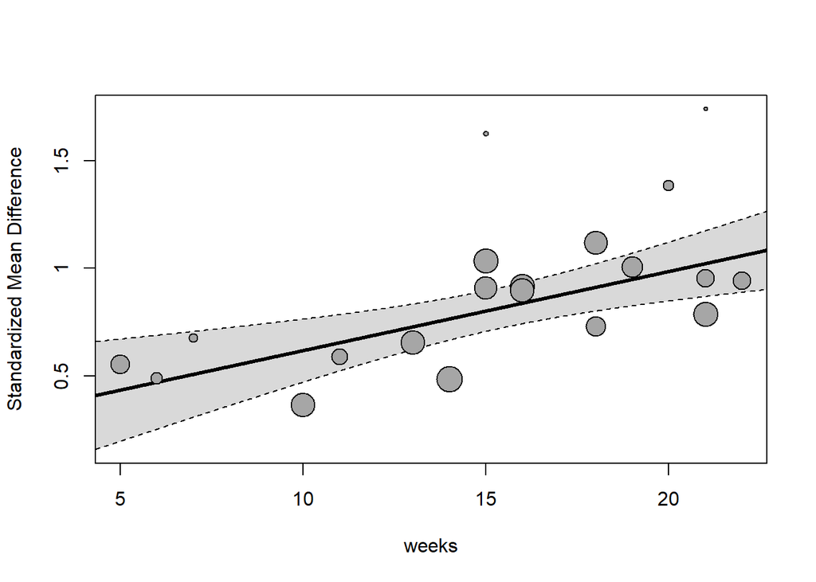

```r
regplot(fit3)
```

And what about the forest plot now?

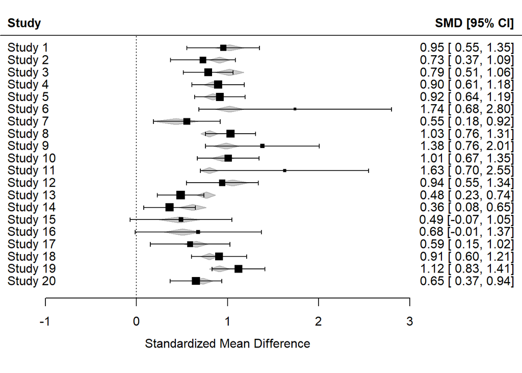

```r
par(mar=c(5,0,0,0))

forest(fit3, header=T)
```